# Difference Plots

# Goal

This notebook compares paired estimates, then plots the calculated gap directly.

The main figure we will use is the Cleveland-style dot plot: categories on one axis, values on a shared quantitative scale, and dots rather than bars.

# Analytic Questions

- How do PRAMS anxiety estimates differ from depression estimates?
- Which states have larger anxiety-minus-depression gaps?
- Why can a dot plot be clearer than paired bars?
- When should we plot the difference directly?

# Load Data

```r
prams <- readr::read_csv("data/real/prams_2011_selected.csv")
```

# Prepare Data

PRAMS values are already aggregated percentages for state/subgroup rows.

In this dataset, `subgroup_cat == "None"` marks the overall state row.

Only some states have both depression and anxiety estimates in this teaching file, so we keep the rows where both are available.

| Data preparation step | Functions in this chunk |
| --- | --- |
| Keep or remove rows | `filter()` |
| Create or change columns | `transmute()` |
| Sort rows | `arrange()` |

```r
state_mental_health <- prams |>
  filter(
    subgroup_cat == "None",
    !is.na(depression_within_3_months_birth),
    !is.na(anxiety_within_3_months_birth)
  ) |>
  transmute(
    location,
    depression = depression_within_3_months_birth,
    anxiety = anxiety_within_3_months_birth,
    difference = anxiety - depression
  ) |>
  arrange(difference)

state_mental_health
```

```
# A tibble: 10 × 4
   location      depression anxiety difference
   <chr>              <dbl>   <dbl>      <dbl>
 1 Wyoming             12.6    10.9     -1.7
 2 Utah                12.5    12.2     -0.300
 3 Maryland            11.4    11.6      0.200
 4 Michigan            14.3    15.2      0.900
 5 West Virginia       15.5    16.6      1.10
 6 Hawaii               4.2     5.6      1.4
 7 Minnesota           10.5    12        1.5
 8 Missouri            12      14.1      2.1
 9 Delaware            11.5    14.3      2.8
10 Wisconsin           13.3    16.2      2.9
```

The difference is measured in percentage points.

- Positive: anxiety estimate is higher than depression estimate.
- Negative: anxiety estimate is lower than depression estimate.
- Zero: the two estimates are equal.

# Paired Estimates As Dots

First, compare the two estimates directly.

A Cleveland dot plot uses position on a common scale. This is usually easier to compare than paired bars.

| Data preparation step | Functions in this chunk |
| --- | --- |
| Choose or rename columns | `select()` |
| Create or change columns | `mutate()` |
| Reshape data | `pivot_longer()` |

| Plot component | Code in this chunk |
| --- | --- |
| Aesthetic mappings | `x`; `y`; `color` |
| Geoms / stats | `geom_point()` |
| `geom_point()` properties | `size` |
| Scales / coordinates / facets / labels | `labs()`; `theme_minimal()` |

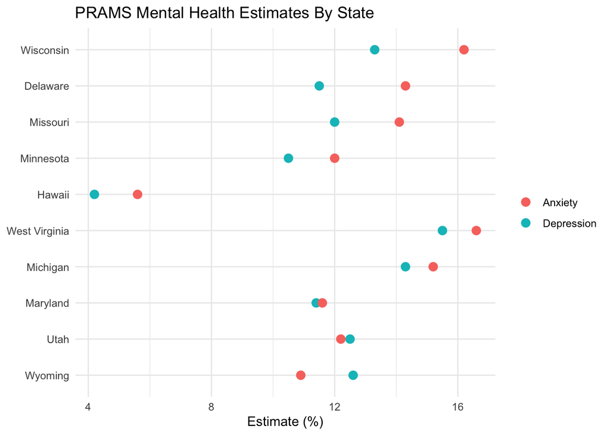

```r
paired_estimates <- state_mental_health |>
  select(location, depression, anxiety) |>
  tidyr::pivot_longer(
    cols = c(depression, anxiety),
    names_to = "measure",
    values_to = "estimate"
  ) |>
  mutate(
    measure = recode(
      measure,
      depression = "Depression",
      anxiety = "Anxiety"
    ),
    location = factor(location, levels = state_mental_health$location)
  )

ggplot(
  paired_estimates,
  aes(x = estimate, y = location, color = measure)
) +
  geom_point(size = 3) +
  labs(
    title = "PRAMS Mental Health Estimates By State",
    x = "Estimate (%)",
    y = NULL,
    color = NULL
  ) +
  theme_minimal()
```

This plot shows both estimates, but the gap still has to be judged by eye.

# Connected Dot Plot

A connected dot plot makes the paired structure more visible.

| Data preparation step | Functions in this chunk |
| --- | --- |
| Create or change columns | `mutate()` |

| Plot component | Code in this chunk |
| --- | --- |
| Aesthetic mappings | `y`; `x`; `xend`; `yend`; `color` |
| Geoms / stats | `geom_segment()`; `geom_point()` |
| `geom_segment()` properties | `color`; `linewidth` |
| `geom_point()` properties (layer 1) | `size` |
| `geom_point()` properties (layer 2) | `size` |
| Scales / coordinates / facets / labels | `scale_color_manual()`; `labs()`; `theme_minimal()` |

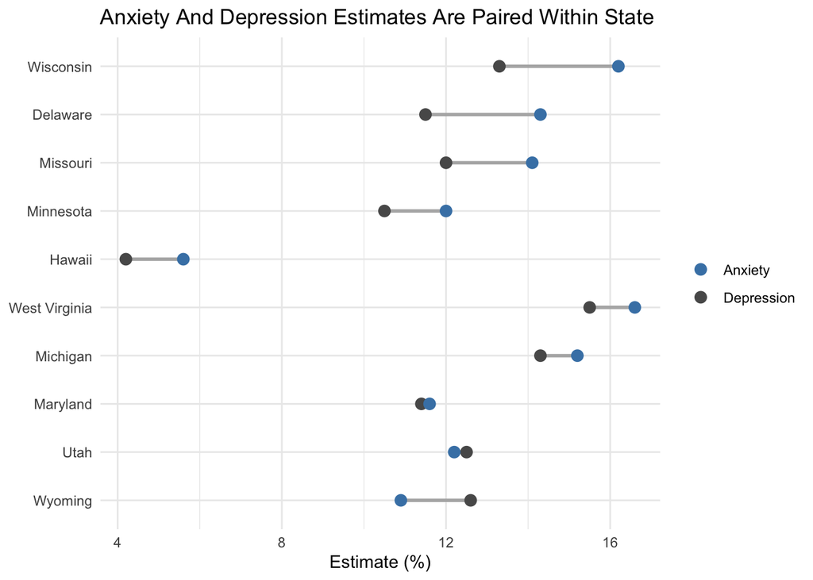

```r
paired_wide <- state_mental_health |>
  mutate(location = factor(location, levels = state_mental_health$location))

ggplot(paired_wide, aes(y = location)) +
  geom_segment(
    aes(x = depression, xend = anxiety, yend = location),
    color = "gray70",
    linewidth = 1
  ) +
  geom_point(aes(x = depression, color = "Depression"), size = 3) +
  geom_point(aes(x = anxiety, color = "Anxiety"), size = 3) +
  scale_color_manual(
    values = c("Depression" = "gray35", "Anxiety" = "steelblue"),
    name = NULL
  ) +
  labs(
    title = "Anxiety And Depression Estimates Are Paired Within State",
    x = "Estimate (%)",
    y = NULL
  ) +
  theme_minimal()
```

This is useful when the reader needs to see both original values and the paired comparison.

Note here how we specified colors with the named vector `c("Depression" = "gray35")` and directly referenced the color in `geom_point`. This is a nice expressive technique.

# Connected Dot Plot With Difference Labels

The same plot can also label the magnitude of the gap. Here the label shows the absolute difference between anxiety and depression in percentage points.

| Data preparation step | Functions in this chunk |
| --- | --- |
| Create or change columns | `mutate()` |

| Plot component | Code in this chunk |
| --- | --- |
| Aesthetic mappings | `y`; `x`; `xend`; `yend`; `color`; `label` |
| Geoms / stats | `geom_segment()`; `geom_point()`; `geom_label()` |
| `geom_label()` properties | `fill`; `size` |

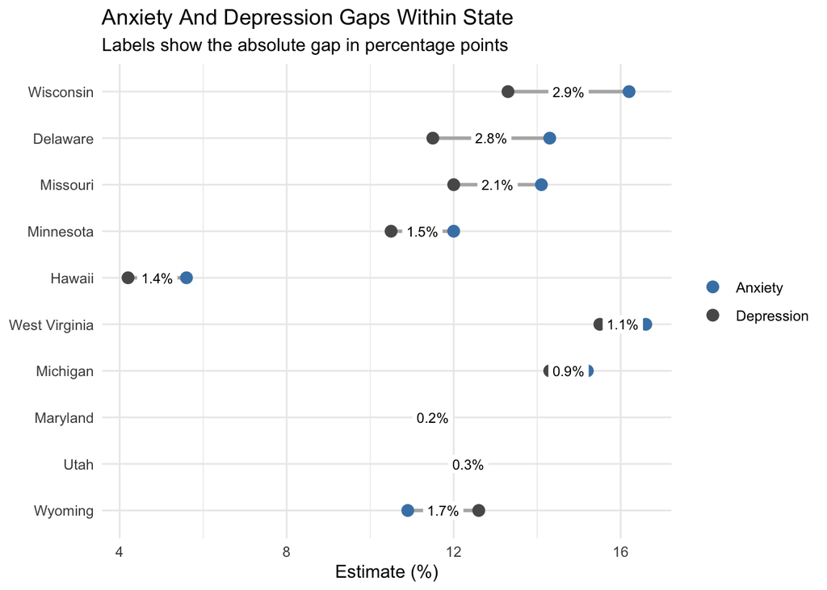

```r
paired_wide_labeled <- paired_wide |>
  mutate(
    label_x = (depression + anxiety) / 2,
    difference_label = paste0(round(abs(difference), 1), "%")
  )

ggplot(paired_wide_labeled, aes(y = location)) +
  geom_segment(
    aes(x = depression, xend = anxiety, yend = location),
    color = "gray70",
    linewidth = 1
  ) +
  geom_point(aes(x = depression, color = "Depression"), size = 3) +
  geom_point(aes(x = anxiety, color = "Anxiety"), size = 3) +
  geom_label(
    aes(x = label_x, label = difference_label),
    fill = "white",
    label.size = 0,
    size = 3
  ) +
  scale_color_manual(
    values = c("Depression" = "gray35", "Anxiety" = "steelblue"),
    name = NULL
  ) +
  labs(
    title = "Anxiety And Depression Gaps Within State",
    subtitle = "Labels show the absolute gap in percentage points",
    x = "Estimate (%)",
    y = NULL
  ) +
  theme_minimal()
```

# Plot The Difference Directly

If the question is about the gap, calculate and plot the gap.

Below we’ll use `reorder()` to make reorder the factor categories by location and the size of the difference.

| Data preparation step | Functions in this chunk |
| --- | --- |
| Create or change columns | `mutate()` |

| Plot component | Code in this chunk |
| --- | --- |
| Aesthetic mappings | `x`; `y`; `xend`; `yend` |
| Geoms / stats | `geom_vline()`; `geom_segment()`; `geom_point()` |
| `geom_vline()` properties | `color` |
| `geom_segment()` properties | `color` |
| `geom_point()` properties | `size`; `color` |
| Scales / coordinates / facets / labels | `labs()`; `theme_minimal()` |

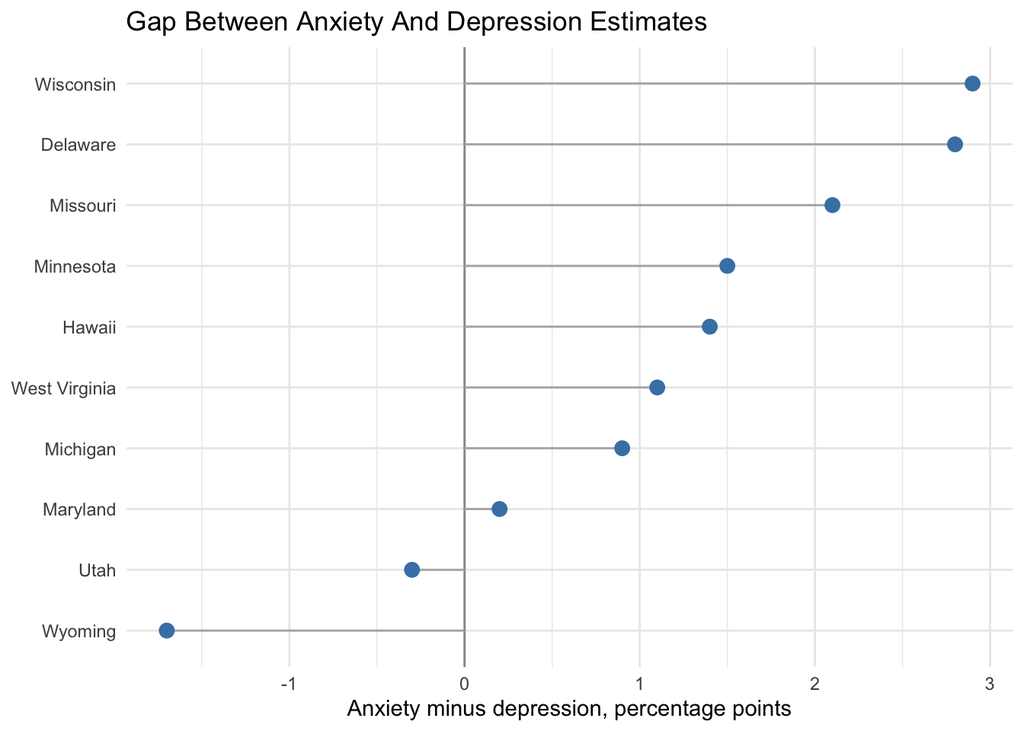

```r
difference_data <- state_mental_health |>
  mutate(location = reorder(location, difference))

ggplot(difference_data, aes(x = difference, y = location)) +
  geom_vline(xintercept = 0, color = "gray60") +
  geom_segment(
    aes(x = 0, xend = difference, yend = location),
    color = "gray70"
  ) +
  geom_point(size = 3, color = "steelblue") +
  labs(
    title = "Gap Between Anxiety And Depression Estimates",
    x = "Anxiety minus depression, percentage points",
    y = NULL
  ) +
  theme_minimal()
```

Most states shown have anxiety estimates slightly higher than depression estimates. Wyoming and Utah are below zero, meaning the depression estimate is higher than the anxiety estimate in those state overall rows.

# Difference Calculations

The plotted value is not one of the original columns. We derive it ourselves with `dplyr`.

```r
state_mental_health |>
  select(location, anxiety, depression, difference)
```

```
# A tibble: 10 × 4
   location      anxiety depression difference
   <chr>           <dbl>      <dbl>      <dbl>
 1 Wyoming          10.9       12.6     -1.7
 2 Utah             12.2       12.5     -0.300
 3 Maryland         11.6       11.4      0.200
 4 Michigan         15.2       14.3      0.900
 5 West Virginia    16.6       15.5      1.10
 6 Hawaii            5.6        4.2      1.4
 7 Minnesota        12         10.5      1.5
 8 Missouri         14.1       12        2.1
 9 Delaware         14.3       11.5      2.8
10 Wisconsin        16.2       13.3      2.9
```

That derived quantity should have clear units and direction.

Here:

- Unit: percentage points.
- Direction: anxiety estimate minus depression estimate.
- Zero: no gap between the two estimates.

# Takeaways

- Cleveland-style dot plots use position on a common scale and avoid unnecessary bar area.
- Connected dot plots are useful when paired original values still matter.
- If the question is about a difference, plot the difference directly.
- Always label whether differences are percentage points, raw units, ratios, or percent changes.